# MA Fitness

Rutuja Gupte

2023-12-13

# Setup functions

- this fits a spline to y=OD versus x=time, and then finds the maximum slope

```r
spline.slope<-function(x, y, n=101, eps=1e-5, span=0.075){
  max(nderiv(loess(log(y) ~ x, degree=1, span=span), x), na.rm=TRUE)
}
```

- used by the function above to get a local (linear) slope around a point

```r
nderiv <- function(fit, x, eps=1e-5){
  (predict(fit, x + eps) - predict(fit, x - eps))/(2 * eps)}
```

### Spline fitting:

First we start by converting everything to log scale. During the exponential growth phase, log(N) is proportional to t where N is the population and t is time. There is noise in the original data. We remove the noise and try to obtain the underlying curve using loess. It gives a smooth curve. Then we use that curve to find local slopes. nderiv gives precise estimate of the local linear slope at every point.

- this fits a spline to y=OD versus x=time, and then finds the time-stamp for maximum slope

```r
spline.time<-function(x, y, n=101, eps=1e-5, span=0.075){
  estimates <- loess(log(y) ~ x, degree=1, span=span)
  slopes <- nderiv(estimates, x)
  return(which.max(slopes))
}
```

**Note that the unit of the time stamp is the number of 15 minute intervals from the beginning of measurement.**

## Reading and cleaning the data

Load all files and setup variables

```r
# merge the list of data frames
d <- dfs %>% reduce(bind_rows)

dates.1 <- seq(mdy(04062023), mdy(04102023), 1)
dates.2 <- seq(mdy(04282023), mdy(11302023), 1)
dates.2 <- c(dates.2, mdy(11022023))
ancestors <- c('H1', 'H2', 'H3', 'D1', 'D2', 'D3')

# these are all the haploid ancestors including the diploids that are supposed to be diploids
ancestors.haploid <- c('H1', 'H2', 'H3', 'D2', 'D3', 'C1', 'C3')

# these are haploids that were intended to be haploids
anc.hap.og <- c('H1', 'H2', 'H3', 'C1', 'C2')

# these are haploids that were intended to be diploids
anc.hap.fake <- c('D2', 'D3')

# this is the only actual diploid control that was diploid
ancestors.diploid <- c('D1')

# this MA line started out as a haploid but ended up as a diploid
fake.haploids <- c(81)

# these MA lines started out as diploids but ended up as haploids
fake.diploids <- c(20, 28, 48, 52, 54, 84, 100)

# these have an aneuploidy of chromosome 3
aneuploids <- c(45, 68, 98)
```

```r
d$batch[d$date %in% dates.1] <- 1
d$batch[d$date %in% dates.2] <- 2

d <- d %>% filter(batch == 2)

d$label <- d$treatment
d$label[d$treatment == 'Blank'] <- '0'
d$label[d$treatment == 'H1'] <- '101'
d$label[d$treatment == 'D1'] <- '102'
d$label[d$treatment == 'H2'] <- '103'
d$label[d$treatment == 'D2'] <- '104'
d$label[d$treatment == 'H3'] <- '105'
d$label[d$treatment == 'D3'] <- '106'
d$label[d$treatment == 'C1'] <- '107'
d$label[d$treatment == 'C3'] <- '109'
d$label <- as.numeric(d$label)

d <- d %>% mutate(category = case_when(label == 0 ~ 'Blank',
                              label > 100 & treatment %in% ancestors.haploid ~ 'Ctrl.H',
                              label > 100 & treatment %in% ancestors.diploid ~ 'Ctrl.D',
                              label %% 2 == 0 ~ 'MA.D',
                              label %% 2 == 1 ~ 'MA.H'))


d <- d %>% mutate(category = ifelse(label %in% fake.diploids, 'MA.H', category))
d <- d %>% mutate(category = ifelse(label %in% fake.haploids, 'MA.D', category))

# Labeling the dates
dates <- d %>% distinct(date)
alphabet <- c('A', 'B', 'C', 'D', 'E')
dates <- dates %>% mutate(day = alphabet)
d <- d %>% left_join(dates, by='date') %>% select(-date)
```

### Additional information about the days

An additional assay was conducted that compared only the control lines with frozen lab stocks. The ancestors used for the experiment were replicates of the frozen lab stocks. However, they demonstrated considerable variance from the lab stocks. This was a cause for concern which led to the conduction of the supplemental assay. The supplemental assay demonstrated that the control lines used for the original assay behaved similar to the lab stocks. Thus it is reasonable to add these values to the dataset before trimming for reasonable values.

# Preliminary exploration

Plot ancestors across all days to visually check for day effects

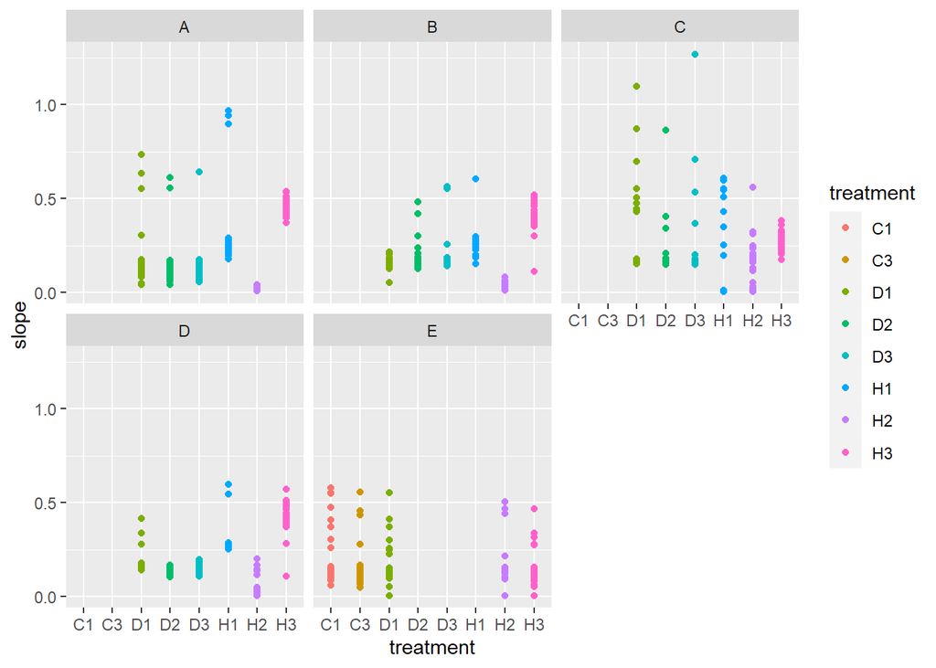

Plotting the distribution of the slope values

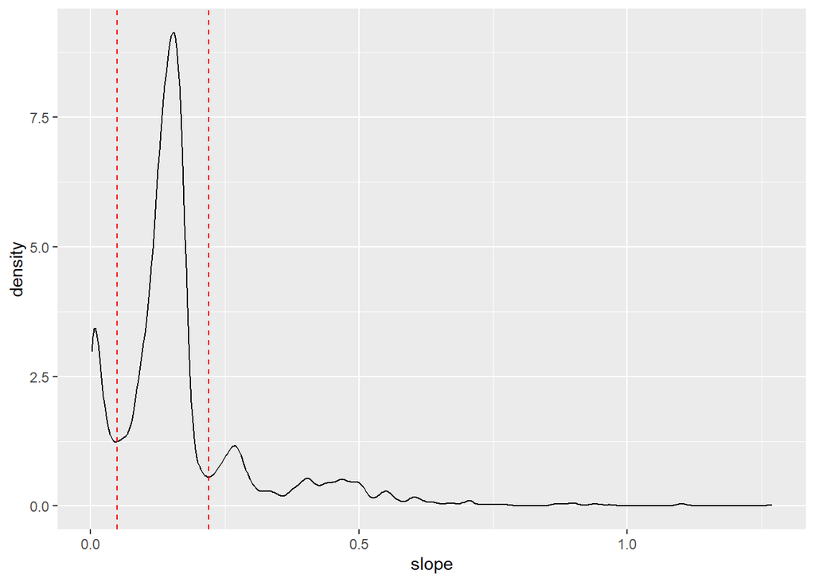

```r
# ci <- c(quantile(d$slope, 0.25) - 1.5* IQR(d$slope),
#         quantile(d$slope, 0.75) + 1.5* IQR(d$slope))

ci <- c(0.05, 0.22)

d %>% ggplot() +
  geom_density(aes(x=slope)) +
  geom_vline(xintercept = ci, color='red', linetype='dashed')
```

Defining the blanks by using a linear model to set a cutoff for the blanks which can then be used to remove the other outliers by predicting the blank values for every day.

```r
blanks <-  d %>% filter(category == 'Blank')
```

visualize the blanks

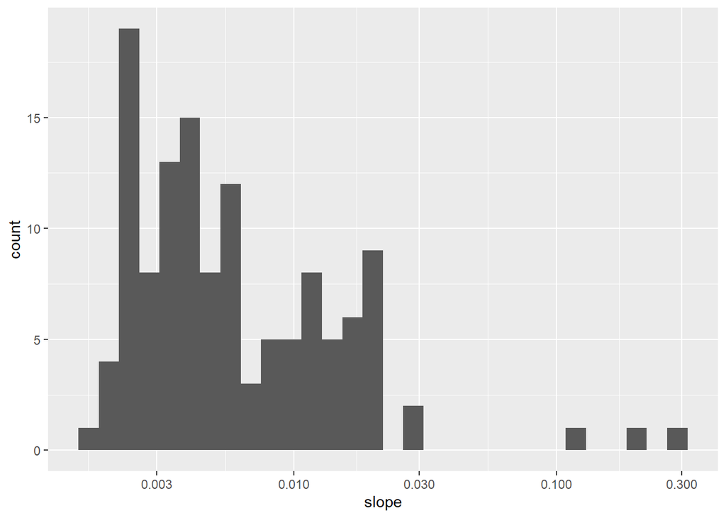

Setting cutoff for blanks around 0.05 and using the good blanks to make blank predictions for each day.

```r
bad.blanks <- blanks %>% filter(slope > 0.05)
good.blanks <- blanks %>% filter(slope < 0.05)

model <- lmer(slope~(1|day), data = good.blanks)
dates.predict <- data.frame(date=distinct(d, day))
dates.predict$null = predict(model, dates.predict)
```

Checking for effects of time (time taken to attain maximum growth rate). Each time stamp is of 15 minutes.

Plotting the low values of time

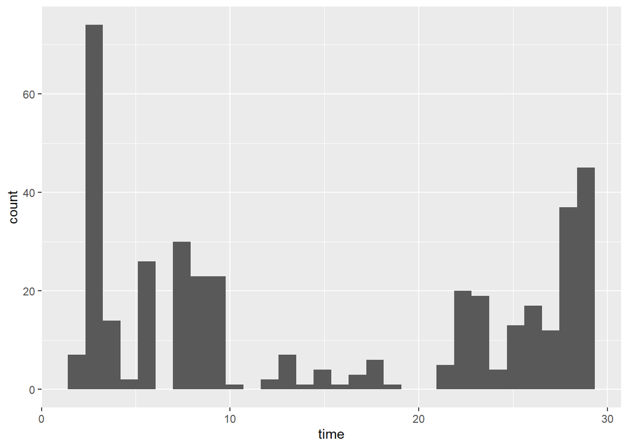

## Error removal

```r
data <- d %>%
  filter(slope > ci[1] & slope < ci[2]) %>%
  anti_join(bad.blanks) %>%
  filter(initial <= final) %>%
  filter(!(treatment %in% anc.hap.fake)) %>%
  filter(time > 20)
```

[output not shown]

Plotting the ancestors again

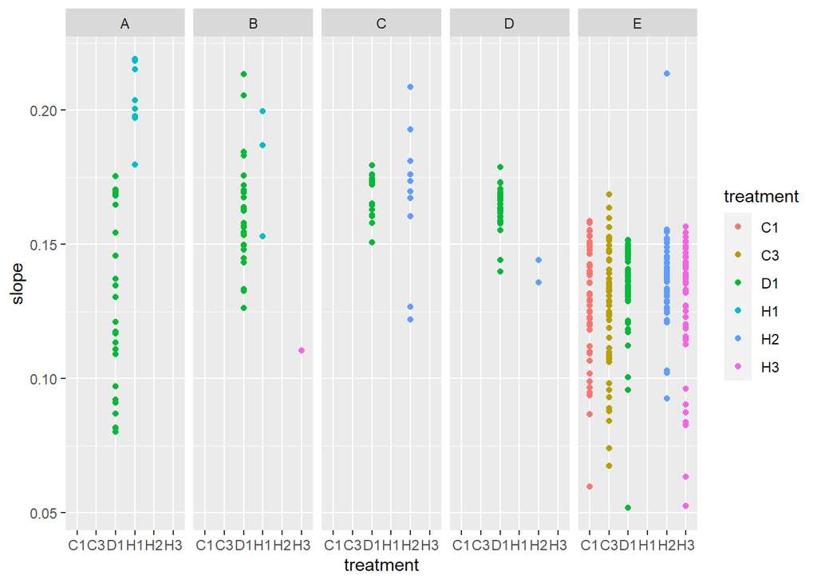

## Preparing for data analysis

```r
df <- data %>%
  select(treatment, label, slope, initial, day, category, time) %>%
  filter(category != 'Blank')

df <- df %>% rename('lineid' = 'treatment')

df$ploidy <- case_when(
  df$category %in% c('Ctrl.H', 'MA.H') ~ 'Haploid',
  df$category %in% c('Ctrl.D', 'MA.D') ~ 'Diploid'
)

df$MA <- case_when(
  df$category %in% c('MA.H', 'MA.D') ~ 'MA',
  df$category %in% c('Ctrl.H', 'Ctrl.D') ~ 'Ctrl',
)
```

# Data Analysis

### Calculating relative fitness

```r
# MA lines
trt <- df %>% filter(label > 0 & label <= 100)
# ancestor lines
ctrl <- df %>% filter(label > 100)

# model to predict the slope of the ancestors of each ploidy with date as a random effect
mod <- lmer(slope ~ ploidy + (1|day), ctrl)

# making predictions for each date
ctrl.predict <- data.frame(distinct(ctrl, day, ploidy))
ctrl.predict$ctrl <- predict(mod, ctrl.predict)

# combining with the MA line dateset
trt <- left_join(trt, ctrl.predict, by=c('day', 'ploidy'))

# calculating relative fitness as the difference between the slope for the MA line and its ancestor
trt$rel.fit <- trt$slope - trt$ctrl

# grouping all the readings for the lines and summarizing by calculating the mean relative fitness
trt <- trt %>% group_by(ploidy, label) %>%
  summarize(rel.fit = mean(rel.fit)) %>%
  ungroup()
# mean and standard deviation for the diploids
mu.dip <- mean(trt$rel.fit[trt$ploidy == 'Diploid'])
sd.dip <- sd(trt$rel.fit[trt$ploidy == 'Diploid'])

# mean and standard deviation for the haploids
mu.hap <- mean(trt$rel.fit[trt$ploidy == 'Haploid'])
sd.hap <- sd(trt$rel.fit[trt$ploidy == 'Haploid'])
```

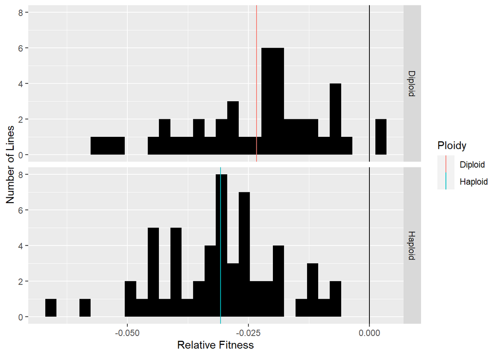

Black line is the 0 line. The haploid MA lines performed worse than the diploid MA lines.

### Using lmer models to test for any differences between the ancestors

```r
null <- lmer(slope ~ 1 + (1|day), ctrl)
full <- lmer(slope ~ ploidy + (1|day), ctrl)
summary(full)
```

```
## Linear mixed model fit by REML ['lmerMod']
## Formula: slope ~ ploidy + (1 | day)
##    Data: ctrl
##
## REML criterion at convergence: -1667.6
##
## Scaled residuals:
##     Min      1Q  Median      3Q     Max
## -3.3899 -0.3930  0.1760  0.5489  3.4249
##
## Random effects:
##  Groups   Name        Variance  Std.Dev.
##  day      (Intercept) 0.0002597 0.01612
##  Residual             0.0005573 0.02361
## Number of obs: 365, groups:  day, 5
##
## Fixed effects:
##               Estimate Std. Error t value
## (Intercept)   0.151926   0.007486  20.296
## ploidyHaploid 0.005653   0.003131   1.805
##
## Correlation of Fixed Effects:
##             (Intr)
## ploidyHapld -0.140
```

```r
mod <- anova(null, full)
```

```
## refitting model(s) with ML (instead of REML)
```

```r
mod
```

```
## Data: ctrl
## Models:
## null: slope ~ 1 + (1 | day)
## full: slope ~ ploidy + (1 | day)
##      npar     AIC     BIC logLik deviance  Chisq Df Pr(>Chisq)
## null    3 -1676.4 -1664.7 841.19  -1682.4
## full    4 -1677.4 -1661.8 842.70  -1685.4 3.0292  1    0.08178 .
## ---
## Signif. codes:  0 '***' 0.001 '**' 0.01 '*' 0.05 '.' 0.1 ' ' 1
```

Ploidy does not have a significant effect on fitness in the ancestors.

### Using lmer models with lineid and date as random effects.

##### Looking for MA-ploidy interaction:

```r
null <- lmer(slope ~ MA + ploidy + (1|day) + (1|lineid), df)
summary(null)
```

```
## Linear mixed model fit by REML ['lmerMod']
## Formula: slope ~ MA + ploidy + (1 | day) + (1 | lineid)
##    Data: df
##
## REML criterion at convergence: -4729.6
##
## Scaled residuals:
##     Min      1Q  Median      3Q     Max
## -3.4015 -0.5529  0.0954  0.5752  3.5943
##
## Random effects:
##  Groups   Name        Variance  Std.Dev.
##  lineid   (Intercept) 0.0001296 0.01139
##  day      (Intercept) 0.0004045 0.02011
##  Residual             0.0006036 0.02457
## Number of obs: 1067, groups:  lineid, 106; day, 5
##
## Fixed effects:
##                Estimate Std. Error t value
## (Intercept)    0.157409   0.010666  14.758
## MAMA          -0.027236   0.005772  -4.718
## ploidyHaploid -0.001878   0.002883  -0.651
##
## Correlation of Fixed Effects:
##             (Intr) MAMA
## MAMA        -0.495
## ploidyHapld -0.217  0.123
```

```r
full <- lmer(slope ~ MA*ploidy + (1|day) + (1|lineid), df)
summary(full)
```

```
## Linear mixed model fit by REML ['lmerMod']
## Formula: slope ~ MA * ploidy + (1 | day) + (1 | lineid)
##    Data: df
##
## REML criterion at convergence: -4723.1
##
## Scaled residuals:
##     Min      1Q  Median      3Q     Max
## -3.3889 -0.5501  0.0927  0.5750  3.5951
##
## Random effects:
##  Groups   Name        Variance  Std.Dev.
##  lineid   (Intercept) 0.0001318 0.01148
##  day      (Intercept) 0.0004066 0.02016
##  Residual             0.0006034 0.02456
## Number of obs: 1067, groups:  lineid, 106; day, 5
##
## Fixed effects:
##                     Estimate Std. Error t value
## (Intercept)         0.151687   0.014750  10.284
## MAMA               -0.021351   0.011927  -1.790
## ploidyHaploid       0.005271   0.012994   0.406
## MAMA:ploidyHaploid -0.007525   0.013331  -0.564
##
## Correlation of Fixed Effects:
##             (Intr) MAMA   pldyHp
## MAMA        -0.776
## ploidyHapld -0.706  0.865
## MAMA:pldyHp  0.688 -0.874 -0.975
```

```r
mod <- anova(null, full)
```

```
## refitting model(s) with ML (instead of REML)
```

```r
mod
```

```
## Data: df
## Models:
## null: slope ~ MA + ploidy + (1 | day) + (1 | lineid)
## full: slope ~ MA * ploidy + (1 | day) + (1 | lineid)
##      npar     AIC     BIC logLik deviance  Chisq Df Pr(>Chisq)
## null    6 -4743.6 -4713.8 2377.8  -4755.6
## full    7 -4742.0 -4707.2 2378.0  -4756.0 0.3269  1     0.5675
```

No significant MA-ploidy interaction

##### Exploring effect of MA on the slope

```r
# lmer for effect of MA
null <- lmer(slope ~ 1 + ploidy + (1|day) + (1|lineid), df)
full <- lmer(slope ~ MA + ploidy + (1|day) + (1|lineid), df)
summary(full)
```

```
## Linear mixed model fit by REML ['lmerMod']
## Formula: slope ~ MA + ploidy + (1 | day) + (1 | lineid)
##    Data: df
##
## REML criterion at convergence: -4729.6
##
## Scaled residuals:
##     Min      1Q  Median      3Q     Max
## -3.4015 -0.5529  0.0954  0.5752  3.5943
##
## Random effects:
##  Groups   Name        Variance  Std.Dev.
##  lineid   (Intercept) 0.0001296 0.01139
##  day      (Intercept) 0.0004045 0.02011
##  Residual             0.0006036 0.02457
## Number of obs: 1067, groups:  lineid, 106; day, 5
##
## Fixed effects:
##                Estimate Std. Error t value
## (Intercept)    0.157409   0.010666  14.758
## MAMA          -0.027236   0.005772  -4.718
## ploidyHaploid -0.001878   0.002883  -0.651
##
## Correlation of Fixed Effects:
##             (Intr) MAMA
## MAMA        -0.495
## ploidyHapld -0.217  0.123
```

```r
mod <- anova(null, full)
```

```
## refitting model(s) with ML (instead of REML)
```

```r
mod
```

```
## Data: df
## Models:
## null: slope ~ 1 + ploidy + (1 | day) + (1 | lineid)
## full: slope ~ MA + ploidy + (1 | day) + (1 | lineid)
##      npar     AIC     BIC logLik deviance  Chisq Df Pr(>Chisq)
## null    5 -4725.7 -4700.9 2367.9  -4735.7
## full    6 -4743.6 -4713.8 2377.8  -4755.6 19.901  1  8.156e-06 ***
## ---
## Signif. codes:  0 '***' 0.001 '**' 0.01 '*' 0.05 '.' 0.1 ' ' 1
```

The MA lines have different slopes than the ancestors

##### Exploring effect of ploidy on the slope

```r
null <- lmer(slope ~ 1 + MA + (1|day) + (1|lineid), df)
full <- lmer(slope ~ ploidy + MA + (1|day) + (1|lineid), df)
summary(full)
```

```
## Linear mixed model fit by REML ['lmerMod']
## Formula: slope ~ ploidy + MA + (1 | day) + (1 | lineid)
##    Data: df
##
## REML criterion at convergence: -4729.6
##
## Scaled residuals:
##     Min      1Q  Median      3Q     Max
## -3.4015 -0.5529  0.0954  0.5752  3.5943
##
## Random effects:
##  Groups   Name        Variance  Std.Dev.
##  lineid   (Intercept) 0.0001296 0.01139
##  day      (Intercept) 0.0004045 0.02011
##  Residual             0.0006036 0.02457
## Number of obs: 1067, groups:  lineid, 106; day, 5
##
## Fixed effects:
##                Estimate Std. Error t value
## (Intercept)    0.157409   0.010666  14.758
## ploidyHaploid -0.001878   0.002883  -0.651
## MAMA          -0.027236   0.005772  -4.718
##
## Correlation of Fixed Effects:
##             (Intr) pldyHp
## ploidyHapld -0.217
## MAMA        -0.495  0.123
```

```r
mod <- anova(null, full)
```

```
## refitting model(s) with ML (instead of REML)
```

```r
mod
```

```
## Data: df
## Models:
## null: slope ~ 1 + MA + (1 | day) + (1 | lineid)
## full: slope ~ ploidy + MA + (1 | day) + (1 | lineid)
##      npar     AIC     BIC logLik deviance  Chisq Df Pr(>Chisq)
## null    5 -4745.2 -4720.3 2377.6  -4755.2
## full    6 -4743.6 -4713.8 2377.8  -4755.6 0.4316  1     0.5112
```

Haploids and diploids do not have different slopes

##### Combining information from the mutation rate dataset

```r
# read the files
mut <- read_delim("pombe_MA_data.txt")
# combine with the relative fitness data
trt2 <- trt %>%
  left_join(mut, by=c('label'='line'))
trt2 <- trt2 %>% select(ploidy.x, label, rel.fit, ploidy.y, ploidy_final,
                        n.SNM, n.indel)
trt2 <- trt2 %>% mutate(mutations = n.SNM + n.indel)
```

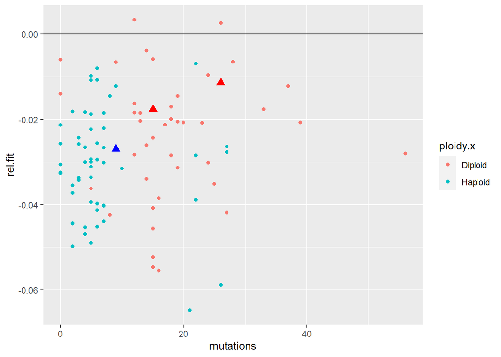

Some diploids have a relative fitness that is greater than 0. Diploids have more mutations than haploids.

##### Using a linear model to explore mutation rate and ploidy interaction

```r
mod <- lm(rel.fit ~ ploidy.x*mutations + ploidy.x + mutations, trt2)
summary(mod)
```

```
##
## Call:
## lm(formula = rel.fit ~ ploidy.x * mutations + ploidy.x + mutations,
##     data = trt2)
##
## Residuals:
##       Min        1Q    Median        3Q       Max
## -0.031997 -0.009074  0.001292  0.008070  0.027014
##
## Coefficients:
##                             Estimate Std. Error t value Pr(>|t|)
## (Intercept)               -2.432e-02  4.295e-03  -5.664 1.54e-07 ***
## ploidy.xHaploid           -5.204e-03  5.015e-03  -1.038    0.302
## mutations                  5.409e-05  2.066e-04   0.262    0.794
## ploidy.xHaploid:mutations -2.260e-04  3.353e-04  -0.674    0.502
## ---
## Signif. codes:  0 '***' 0.001 '**' 0.01 '*' 0.05 '.' 0.1 ' ' 1
##
## Residual standard error: 0.01347 on 96 degrees of freedom
## Multiple R-squared:  0.07644,    Adjusted R-squared:  0.04758
## F-statistic: 2.649 on 3 and 96 DF,  p-value: 0.05326
```

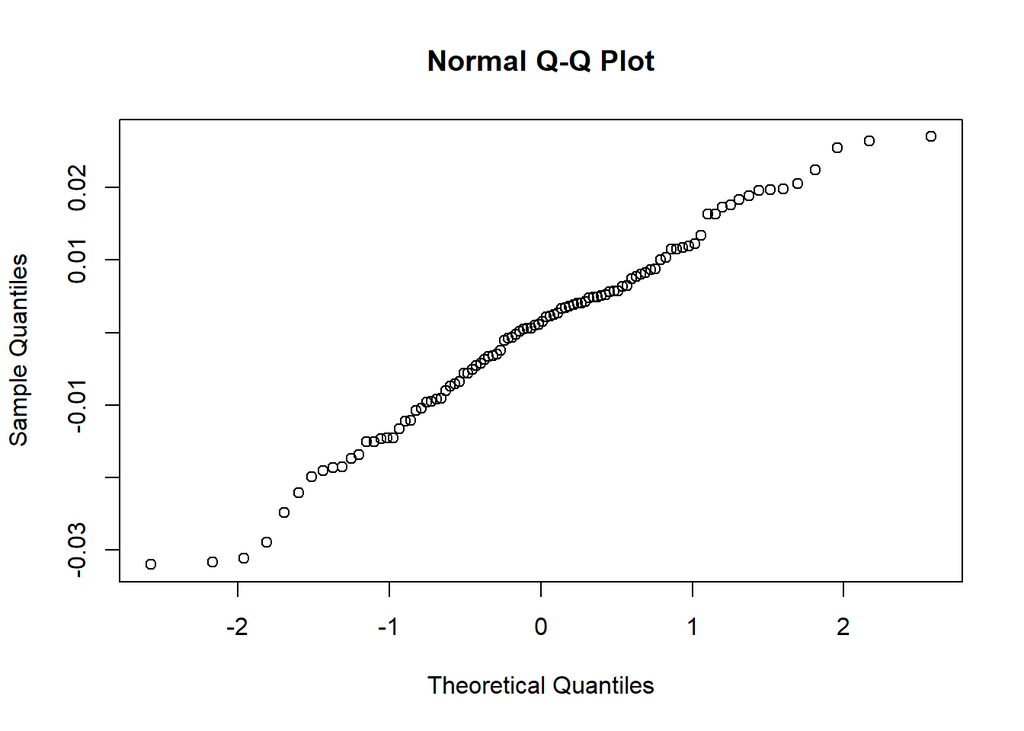

```r
qqnorm(resid(mod))
```

##### Linear model with no mutation rate and ploidy interactions

```r
mod <- lm(rel.fit ~ ploidy.x + mutations, trt2)
summary(mod)
```

```
##
## Call:
## lm(formula = rel.fit ~ ploidy.x + mutations, data = trt2)
##
## Residuals:
##       Min        1Q    Median        3Q       Max
## -0.033647 -0.008821  0.001662  0.008393  0.026472
##
## Coefficients:
##                   Estimate Std. Error t value Pr(>|t|)
## (Intercept)     -0.0227522  0.0035962  -6.327 7.72e-09 ***
## ploidy.xHaploid -0.0077642  0.0032649  -2.378   0.0194 *
## mutations       -0.0000317  0.0001622  -0.195   0.8455
## ---
## Signif. codes:  0 '***' 0.001 '**' 0.01 '*' 0.05 '.' 0.1 ' ' 1
##
## Residual standard error: 0.01343 on 97 degrees of freedom
## Multiple R-squared:  0.07207,    Adjusted R-squared:  0.05294
## F-statistic: 3.767 on 2 and 97 DF,  p-value: 0.02657
```

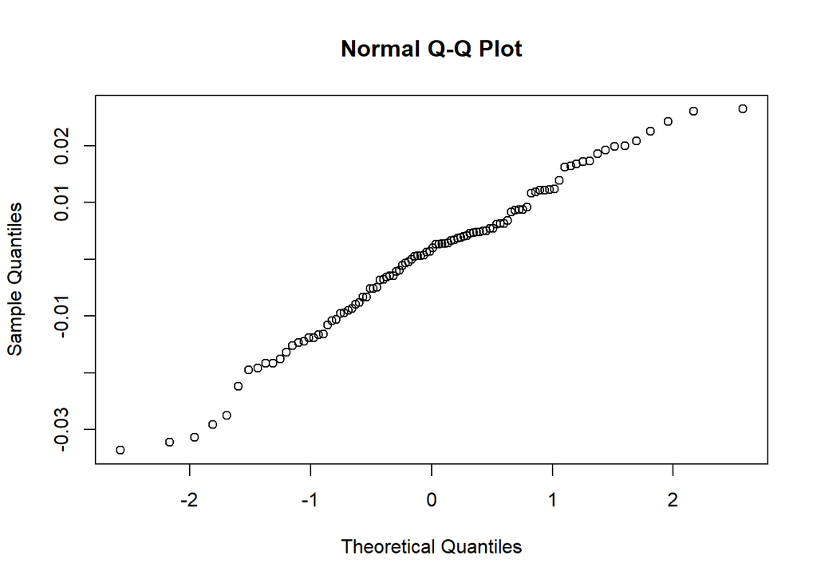

```r
qqnorm(resid(mod))
```

##### Linear model with only the mutations

```r
mod <- lm(rel.fit ~ mutations, trt2)
summary(mod)
```

```
##
## Call:
## lm(formula = rel.fit ~ mutations, data = trt2)
##
## Residuals:
##       Min        1Q    Median        3Q       Max
## -0.039005 -0.009004 -0.000691  0.009219  0.030822
##
## Coefficients:
##               Estimate Std. Error t value Pr(>|t|)
## (Intercept) -0.0296943  0.0021495 -13.815   <2e-16 ***
## mutations    0.0001843  0.0001376   1.339    0.184
## ---
## Signif. codes:  0 '***' 0.001 '**' 0.01 '*' 0.05 '.' 0.1 ' ' 1
##
## Residual standard error: 0.01374 on 98 degrees of freedom
## Multiple R-squared:  0.01798,    Adjusted R-squared:  0.007956
## F-statistic: 1.794 on 1 and 98 DF,  p-value: 0.1835
```

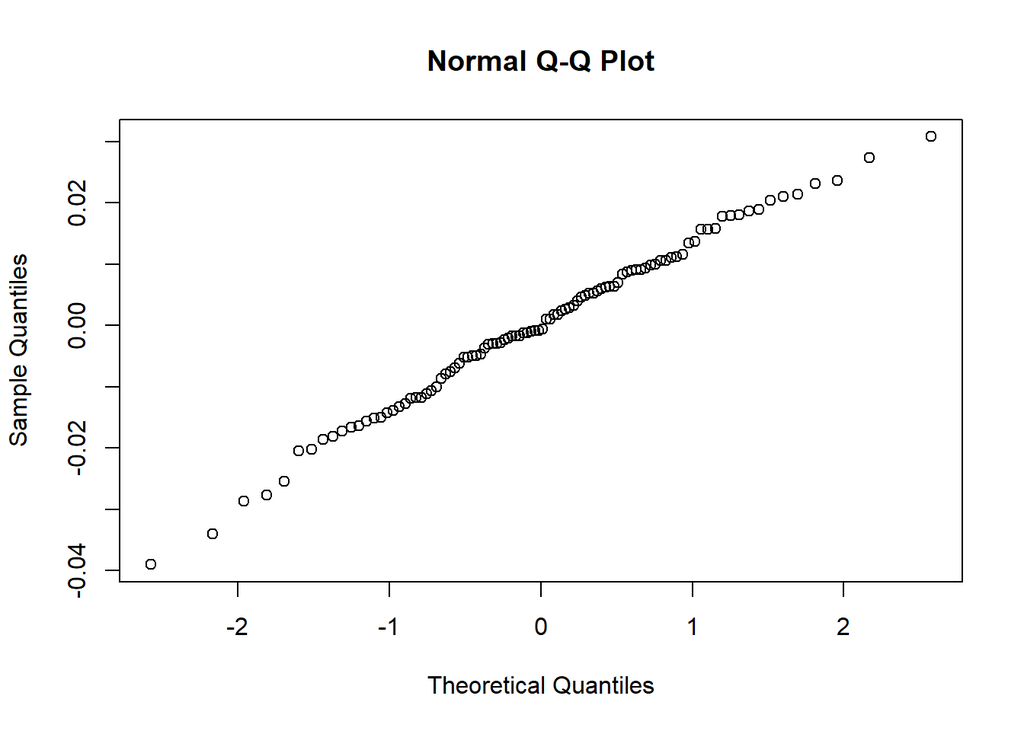

```r
qqnorm(resid(mod))
```

##### Combining the mutation dataset with the entire assay data

```r
mut_join <- trt2 %>% select(label, mutations)
df <- df %>% left_join(mut_join) %>%
  mutate(mutations = ifelse(is.na(mutations), 0, mutations))
```

##### Mutation rate - ploidy interaction

```r
null <- lmer(slope ~ mutations + ploidy + (1|day) + (1|lineid), df)
summary(null)
```

```
## Linear mixed model fit by REML ['lmerMod']
## Formula: slope ~ mutations + ploidy + (1 | day) + (1 | lineid)
##    Data: df
##
## REML criterion at convergence: -4704.2
##
## Scaled residuals:
##     Min      1Q  Median      3Q     Max
## -3.5565 -0.5406  0.0626  0.5779  3.4974
##
## Random effects:
##  Groups   Name        Variance  Std.Dev.
##  lineid   (Intercept) 0.0001747 0.01322
##  day      (Intercept) 0.0003594 0.01896
##  Residual             0.0006029 0.02455
## Number of obs: 1067, groups:  lineid, 106; day, 5
##
## Fixed effects:
##                 Estimate Std. Error t value
## (Intercept)    0.1360336  0.0094031  14.467
## mutations     -0.0002130  0.0001861  -1.144
## ploidyHaploid -0.0026332  0.0037890  -0.695
##
## Correlation of Fixed Effects:
##             (Intr) muttns
## mutations   -0.345
## ploidyHapld -0.354  0.555
```

```r
full <- lmer(slope ~ mutations*ploidy + (1|day) + (1|lineid), df)
summary(full)
```

```
## Linear mixed model fit by REML ['lmerMod']
## Formula: slope ~ mutations * ploidy + (1 | day) + (1 | lineid)
##    Data: df
##
## REML criterion at convergence: -4692.2
##
## Scaled residuals:
##     Min      1Q  Median      3Q     Max
## -3.5425 -0.5379  0.0697  0.5717  3.4997
##
## Random effects:
##  Groups   Name        Variance  Std.Dev.
##  lineid   (Intercept) 0.0001725 0.01313
##  day      (Intercept) 0.0003623 0.01903
##  Residual             0.0006029 0.02455
## Number of obs: 1067, groups:  lineid, 106; day, 5
##
## Fixed effects:
##                           Estimate Std. Error t value
## (Intercept)              0.1324813  0.0097710  13.559
## mutations               -0.0000168  0.0002335  -0.072
## ploidyHaploid            0.0029826  0.0055406   0.538
## mutations:ploidyHaploid -0.0005293  0.0003823  -1.384
##
## Correlation of Fixed Effects:
##             (Intr) muttns pldyHp
## mutations   -0.422
## ploidyHapld -0.424  0.745
## mttns:pldyH  0.264 -0.608 -0.732
```

```r
mod <- anova(null, full)
```

```
## refitting model(s) with ML (instead of REML)
```

```r
mod
```

```
## Data: df
## Models:
## null: slope ~ mutations + ploidy + (1 | day) + (1 | lineid)
## full: slope ~ mutations * ploidy + (1 | day) + (1 | lineid)
##      npar     AIC     BIC logLik deviance  Chisq Df Pr(>Chisq)
## null    6 -4725.1 -4695.2 2368.5  -4737.1
## full    7 -4725.0 -4690.2 2369.5  -4739.0 1.9465  1      0.163
```

No significant interaction in number of mutations and ploidy

##### Effect of mutations

```r
null <- lmer(slope ~ 1 + ploidy + (1|day) + (1|lineid), df)
full <- lmer(slope ~ mutations + ploidy + (1|day) + (1|lineid), df)
summary(full)
```

```
## Linear mixed model fit by REML ['lmerMod']
## Formula: slope ~ mutations + ploidy + (1 | day) + (1 | lineid)
##    Data: df
##
## REML criterion at convergence: -4704.2
##
## Scaled residuals:
##     Min      1Q  Median      3Q     Max
## -3.5565 -0.5406  0.0626  0.5779  3.4974
##
## Random effects:
##  Groups   Name        Variance  Std.Dev.
##  lineid   (Intercept) 0.0001747 0.01322
##  day      (Intercept) 0.0003594 0.01896
##  Residual             0.0006029 0.02455
## Number of obs: 1067, groups:  lineid, 106; day, 5
##
## Fixed effects:
##                 Estimate Std. Error t value
## (Intercept)    0.1360336  0.0094031  14.467
## mutations     -0.0002130  0.0001861  -1.144
## ploidyHaploid -0.0026332  0.0037890  -0.695
##
## Correlation of Fixed Effects:
##             (Intr) muttns
## mutations   -0.345
## ploidyHapld -0.354  0.555
```

```r
mod <- anova(null, full)
```

```
## refitting model(s) with ML (instead of REML)
```

```r
mod
```

```
## Data: df
## Models:
## null: slope ~ 1 + ploidy + (1 | day) + (1 | lineid)
## full: slope ~ mutations + ploidy + (1 | day) + (1 | lineid)
##      npar     AIC     BIC logLik deviance  Chisq Df Pr(>Chisq)
## null    5 -4725.7 -4700.9 2367.9  -4735.7
## full    6 -4725.1 -4695.2 2368.5  -4737.1 1.3234  1       0.25
```

No significant fitness effects of number of mutations.

###### Effect of ploidy

```r
null <- lmer(slope ~ 1 + mutations + (1|day) + (1|lineid), df)
full <- lmer(slope ~ ploidy + mutations + (1|day) + (1|lineid), df)
summary(full)
```

```
## Linear mixed model fit by REML ['lmerMod']
## Formula: slope ~ ploidy + mutations + (1 | day) + (1 | lineid)
##    Data: df
##
## REML criterion at convergence: -4704.2
##
## Scaled residuals:
##     Min      1Q  Median      3Q     Max
## -3.5565 -0.5406  0.0626  0.5779  3.4974
##
## Random effects:
##  Groups   Name        Variance  Std.Dev.
##  lineid   (Intercept) 0.0001747 0.01322
##  day      (Intercept) 0.0003594 0.01896
##  Residual             0.0006029 0.02455
## Number of obs: 1067, groups:  lineid, 106; day, 5
##
## Fixed effects:
##                 Estimate Std. Error t value
## (Intercept)    0.1360336  0.0094031  14.467
## ploidyHaploid -0.0026332  0.0037890  -0.695
## mutations     -0.0002130  0.0001861  -1.144
##
## Correlation of Fixed Effects:
##             (Intr) pldyHp
## ploidyHapld -0.354
## mutations   -0.345  0.555
```

```r
mod <- anova(null, full)
```

```
## refitting model(s) with ML (instead of REML)
```

```r
mod
```

```
## Data: df
## Models:
## null: slope ~ 1 + mutations + (1 | day) + (1 | lineid)
## full: slope ~ ploidy + mutations + (1 | day) + (1 | lineid)
##      npar     AIC     BIC logLik deviance  Chisq Df Pr(>Chisq)
## null    5 -4726.6 -4701.7 2368.3  -4736.6
## full    6 -4725.1 -4695.2 2368.5  -4737.1 0.4927  1     0.4827
```